# Relatório 02 - Como usar o projeto Relatório

Maria Clara Figueiredo Coelho

29/04/2022

# 1 Objetivo

Descrever como elaborar e compartilhar relatórios a partir do Github:

- Cadastro no GitHub
- Instalação do Git
- Pacotes necessários no RStudio
- Como criar e clonar um repositório no Github
- Utilizando o RMarkdown
- Como comitar um relatório

# 2 Apresentação do relatório

Os relatórios são criados e estruturados no RStudio e compartilhados a partir da exportação dos dados no githut por meio de **Repositórios**. Abaixo será descrito o passo a passo básico para o desenvolvimento de um relatório.

## 2.1 Cadastro no Github

Para se cadastrar no Github entre na seguinte página: [Cadastro no Github](https://github.com/signup?ref_cta=Sign+up&ref_loc=header+logged+out&ref_page=%2F&source=header-home)

## 2.2 Instalação do Git

É necessário fazer o download do Git para utilizar a ferramenta atrelada ao RStudio.

Para isso, basta acessar: [Download Git](https://git-scm.com/downloads)

## 2.3 Pacotes necessários no RStudio

Para o desenvolvimento de relatórios é necessários que alguns pacotes sejam instalados no RStudio, são eles: *knitr*, *rmarkdown* e *tinytex*

Para isso basta acessar a aba **Packages**, que está no 4° quadrante, e busvar pelo nome dos pacotes.

## 2.4 Como criar e clonar um repositório no Github

- Voltando ao Github, será necessário criar um repositório, conforme demonstração abaixo:

[figure not shown]

Criando novo repositório

Em seguida, é necessário nomear o repositório, deixá-lo publico é selecionar a opção *Add a README file*:

[figure not shown]

Criando novo repositório

- Em seguida, é necessário copiar o HTTPS para criar o projeto no RStudio:

[figure not shown]

Para copiar o HTTPS do Repositório

- O próximo passo é abrir o RStudio, ir à opção *File* e abrir um novo projeto na opção *New project*:

[figure not shown]

Abrindo um novo projeto

Abrirá uma aba e deve ser selecionada a opção *Version control*, em seguida *Git*, que levará à aba onde deverá ser colado o HTTPS do repositório:

[figure not shown]

HTTPS para RStudio

## 2.5 Utilizando o RMarkdown

- O RMarkdown será a ferramenta utilizada para escrever em si o relatório, a partir opção *Knit* para gerar o arquivo html.

## 2.6 Como comitar um relatório

No 2° quadrante, teremos opção Git, onde deveremos selecionar a o *Commit*:

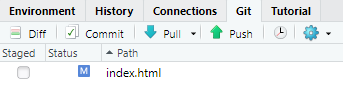

Comitando o relatório

- A ação seguinte deverá ser selecionar os arquivos, fazer um comentário no quadrante *Commit Message*, selecionar o botão *Commit* e em seguida selecionar o *Push*:

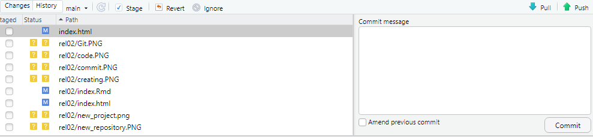

Comitando o relatório